# Week8-Lab VII

y = b0 + b1x

b0 = -642.8 b1 = 5242.2

y = -642.8 + (5242.2)*x

Relationship between runs vs bat_avg is positive, linear and relatively strong.

2. How does this relationship compare to the relationship between runs and at_bats? Use the R2 values from the two model summaries to compare. Does your variable seem to predict runs better than at_bats? How can you tell?

Relationship between runs and bat_avg seems to be more stronger than runs and at_bats.

R2 value for runs and bat_avg = 0.6561

R2 value for runs and at_bats = 0.3729

The variable “bat_avg” is a much better predictor of “runs” than the variable “at_bats” as is indcated by the R2 value.

3. Now that you can summarize the linear relationship between two variables, investigate the relationships between runs and each of the other five traditional variables. Which variable best predicts runs? Support your conclusion using the graphical and numerical methods we’ve discussed (for the sake of conciseness, only include output for the best variable, not all five).

```r
hits <- lm(runs ~ hits, data = mlb11)
summary(hits)
```

```
##
## Call:
## lm(formula = runs ~ hits, data = mlb11)
##
## Residuals:
##      Min       1Q   Median       3Q      Max
## -103.718  -27.179   -5.233   19.322  140.693
##
## Coefficients:
##              Estimate Std. Error t value Pr(>|t|)
## (Intercept) -375.5600   151.1806  -2.484   0.0192 *
## hits           0.7589     0.1071   7.085 1.04e-07 ***
## ---
## Signif. codes:  0 '***' 0.001 '**' 0.01 '*' 0.05 '.' 0.1 ' ' 1
##
## Residual standard error: 50.23 on 28 degrees of freedom
## Multiple R-squared:  0.6419, Adjusted R-squared:  0.6292
## F-statistic:  50.2 on 1 and 28 DF,  p-value: 1.043e-07
```

```r
homeruns <- lm(runs ~ homeruns, data = mlb11)
summary(homeruns)
```

```
##
## Call:
## lm(formula = runs ~ homeruns, data = mlb11)
##
## Residuals:
##     Min      1Q  Median      3Q     Max
## -91.615 -33.410   3.231  24.292 104.631
##
## Coefficients:
##             Estimate Std. Error t value Pr(>|t|)
## (Intercept) 415.2389    41.6779   9.963 1.04e-10 ***
## homeruns      1.8345     0.2677   6.854 1.90e-07 ***
## ---
## Signif. codes:  0 '***' 0.001 '**' 0.01 '*' 0.05 '.' 0.1 ' ' 1
##
## Residual standard error: 51.29 on 28 degrees of freedom
## Multiple R-squared:  0.6266, Adjusted R-squared:  0.6132
## F-statistic: 46.98 on 1 and 28 DF,  p-value: 1.9e-07
```

```r
bat_avg <- lm(runs ~ bat_avg, data = mlb11)
summary(bat_avg)
```

```
##
## Call:
## lm(formula = runs ~ bat_avg, data = mlb11)
##
## Residuals:
##     Min      1Q  Median      3Q     Max
## -94.676 -26.303  -5.496  28.482 131.113
##
## Coefficients:
##             Estimate Std. Error t value Pr(>|t|)
## (Intercept)   -642.8      183.1  -3.511  0.00153 **
## bat_avg       5242.2      717.3   7.308 5.88e-08 ***
## ---
## Signif. codes:  0 '***' 0.001 '**' 0.01 '*' 0.05 '.' 0.1 ' ' 1
##
## Residual standard error: 49.23 on 28 degrees of freedom
## Multiple R-squared:  0.6561, Adjusted R-squared:  0.6438
## F-statistic: 53.41 on 1 and 28 DF,  p-value: 5.877e-08
```

```r
strikeouts <- lm(runs ~ strikeouts, data = mlb11)
summary(strikeouts)
```

```
##
## Call:
## lm(formula = runs ~ strikeouts, data = mlb11)
##
## Residuals:
##     Min      1Q  Median      3Q     Max
## -132.27  -46.95  -11.92   55.14  169.76
##
## Coefficients:
##              Estimate Std. Error t value Pr(>|t|)
## (Intercept) 1054.7342   151.7890   6.949 1.49e-07 ***
## strikeouts    -0.3141     0.1315  -2.389   0.0239 *
## ---
## Signif. codes:  0 '***' 0.001 '**' 0.01 '*' 0.05 '.' 0.1 ' ' 1
##
## Residual standard error: 76.5 on 28 degrees of freedom
## Multiple R-squared:  0.1694, Adjusted R-squared:  0.1397
## F-statistic: 5.709 on 1 and 28 DF,  p-value: 0.02386
```

```r
stolen_bases <- lm(runs ~ stolen_bases, data = mlb11)
summary(stolen_bases)
```

```
##
## Call:
## lm(formula = runs ~ stolen_bases, data = mlb11)
##
## Residuals:
##     Min      1Q  Median      3Q     Max
## -139.94  -62.87   10.01   38.54  182.49
##
## Coefficients:
##              Estimate Std. Error t value Pr(>|t|)
## (Intercept)  677.3074    58.9751  11.485 4.17e-12 ***
## stolen_bases   0.1491     0.5211   0.286    0.777
## ---
## Signif. codes:  0 '***' 0.001 '**' 0.01 '*' 0.05 '.' 0.1 ' ' 1
##
## Residual standard error: 83.82 on 28 degrees of freedom
## Multiple R-squared:  0.002914,   Adjusted R-squared:  -0.0327
## F-statistic: 0.08183 on 1 and 28 DF,  p-value: 0.7769
```

```r
wins <- lm(runs ~ wins, data = mlb11)
summary(wins)
```

```
##
## Call:
## lm(formula = runs ~ wins, data = mlb11)
##
## Residuals:
##      Min       1Q   Median       3Q      Max
## -145.450  -47.506   -7.482   47.346  142.186
##
## Coefficients:
##             Estimate Std. Error t value Pr(>|t|)
## (Intercept)  342.121     89.223   3.834 0.000654 ***
## wins           4.341      1.092   3.977 0.000447 ***
## ---
## Signif. codes:  0 '***' 0.001 '**' 0.01 '*' 0.05 '.' 0.1 ' ' 1
##
## Residual standard error: 67.1 on 28 degrees of freedom
## Multiple R-squared:  0.361,  Adjusted R-squared:  0.3381
## F-statistic: 15.82 on 1 and 28 DF,  p-value: 0.0004469
```

```r
cor(mlb11$runs, mlb11$hits)
```

```
## [1] 0.8012108
```

```r
cor(mlb11$runs, mlb11$homeruns)
```

```
## [1] 0.7915577
```

```r
cor(mlb11$runs, mlb11$bat_avg)
```

```
## [1] 0.8099859
```

```r
cor(mlb11$runs, mlb11$strikeouts)
```

```
## [1] -0.4115312
```

```r
cor(mlb11$runs, mlb11$stolen_bases)
```

```
## [1] 0.05398141
```

```r
cor(mlb11$runs, mlb11$wins)
```

```
## [1] 0.6008088
```

Comparing R2 values and correlation coefficient for remaining variables

hits => Multiple R-squared: 0.6419

homeruns => Multiple R-squared: 0.6266

bat_avg => Multiple R-squared: 0.6561

strikeouts => Multiple R-squared: 0.1694

stolen_bases => Multiple R-squared: 0.002914

wins => Multiple R-squared: 0.361

hits => Correlation Coefficent: 0.8012108

homeruns => Correlation Coefficent: 0.7915577

bat_avg => Correlation Coefficent: 0.8099859

strikeouts => Correlation Coefficent: -0.4115312

stolen_bases => Correlation Coefficent: 0.05398141

wins => Correlation Coefficent: 0.6008088

After running the summary statistics for all the variables, the variable which best predicts the runs based on R2 happened to be bat_avg.

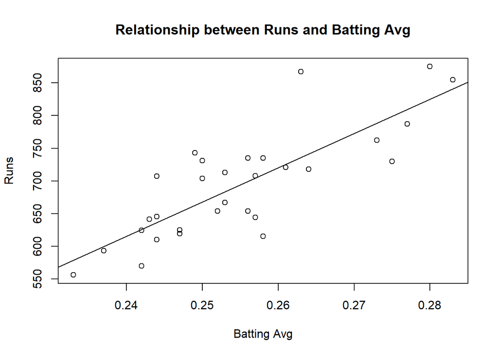

```r
plot(mlb11$runs ~ mlb11$bat_avg, main = "Relationship between Runs and Batting Avg", xlab = "Batting Avg", ylab = "Runs")
bat_avg <- lm(runs ~ bat_avg, data = mlb11)
abline(bat_avg)
```

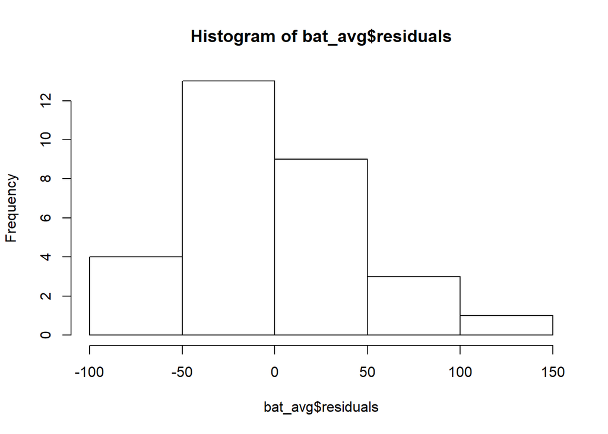

```r
hist(bat_avg$residuals)
```

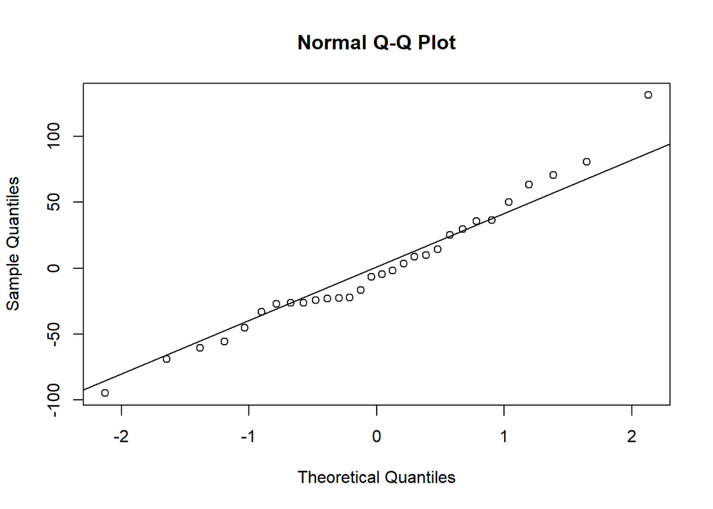

```r
qqnorm(bat_avg$residuals)
qqline(bat_avg$residuals)
```

4. Now examine the three newer variables. These are the statistics used by the author of Moneyball to predict a teams success. In general, are they more or less effective at predicting runs that the old variables? Explain using appropriate graphical and numerical evidence. Of all ten variables we’ve analyzed, which seems to be the best predictor of runs? Using the limited (or not so limited) information you know about these baseball statistics, does your result make sense?

Three new variables new_onbase new_slug new_obs

```r
new_onbase <- lm(runs ~ new_onbase, data = mlb11)
summary(new_onbase)
```

```
##
## Call:
## lm(formula = runs ~ new_onbase, data = mlb11)
##
## Residuals:
##     Min      1Q  Median      3Q     Max
## -58.270 -18.335   3.249  19.520  69.002
##
## Coefficients:
##             Estimate Std. Error t value Pr(>|t|)
## (Intercept)  -1118.4      144.5  -7.741 1.97e-08 ***
## new_onbase    5654.3      450.5  12.552 5.12e-13 ***
## ---
## Signif. codes:  0 '***' 0.001 '**' 0.01 '*' 0.05 '.' 0.1 ' ' 1
##
## Residual standard error: 32.61 on 28 degrees of freedom
## Multiple R-squared:  0.8491, Adjusted R-squared:  0.8437
## F-statistic: 157.6 on 1 and 28 DF,  p-value: 5.116e-13
```

```r
new_slug <- lm(runs ~ new_slug, data = mlb11)
summary(new_slug)
```

```
##
## Call:
## lm(formula = runs ~ new_slug, data = mlb11)
##
## Residuals:
##    Min     1Q Median     3Q    Max
## -45.41 -18.66  -0.91  16.29  52.29
##
## Coefficients:
##             Estimate Std. Error t value Pr(>|t|)
## (Intercept)  -375.80      68.71   -5.47 7.70e-06 ***
## new_slug     2681.33     171.83   15.61 2.42e-15 ***
## ---
## Signif. codes:  0 '***' 0.001 '**' 0.01 '*' 0.05 '.' 0.1 ' ' 1
##
## Residual standard error: 26.96 on 28 degrees of freedom
## Multiple R-squared:  0.8969, Adjusted R-squared:  0.8932
## F-statistic: 243.5 on 1 and 28 DF,  p-value: 2.42e-15
```

```r
new_obs <- lm(runs ~ new_obs, data = mlb11)
summary(new_obs)
```

```
##
## Call:
## lm(formula = runs ~ new_obs, data = mlb11)
##
## Residuals:
##     Min      1Q  Median      3Q     Max
## -43.456 -13.690   1.165  13.935  41.156
##
## Coefficients:
##             Estimate Std. Error t value Pr(>|t|)
## (Intercept)  -686.61      68.93  -9.962 1.05e-10 ***
## new_obs      1919.36      95.70  20.057  < 2e-16 ***
## ---
## Signif. codes:  0 '***' 0.001 '**' 0.01 '*' 0.05 '.' 0.1 ' ' 1
##
## Residual standard error: 21.41 on 28 degrees of freedom
## Multiple R-squared:  0.9349, Adjusted R-squared:  0.9326
## F-statistic: 402.3 on 1 and 28 DF,  p-value: < 2.2e-16
```

```r
cor(mlb11$runs, mlb11$new_onbase)
```

```
## [1] 0.9214691
```

```r
cor(mlb11$runs, mlb11$new_slug)
```

```
## [1] 0.9470324
```

```r
cor(mlb11$runs, mlb11$new_obs)
```

```
## [1] 0.9669163
```

new_onbase => Multiple R-squared: 0.8491

new_slug => Multiple R-squared: 0.8969

new_onbase => Correlation Coefficent: 0.9214691

new_slug => Correlation Coefficent: 0.9470324

new_obs => Correlation Coefficent: 0.9669163

Earlier Best prediction model was based on bats_avg based on tradition variables

bat_avg => Multiple R-squared: 0.6561

bat_avg => Correlation Coefficent: 0.8099859

The newer variable seems to predict runs better than old variables. The R2 value for newer variables are higher than that of old variable. Given that the newer variables represent more advanced statistics of baseball it does make sense that they are better predictor of runs. So in summary result does make sense.

Of the new three variables the relationship between runs and new_obs variable has the highest R2. It appears to be best predictor of runs.

Below are the plots for all three new varaibles

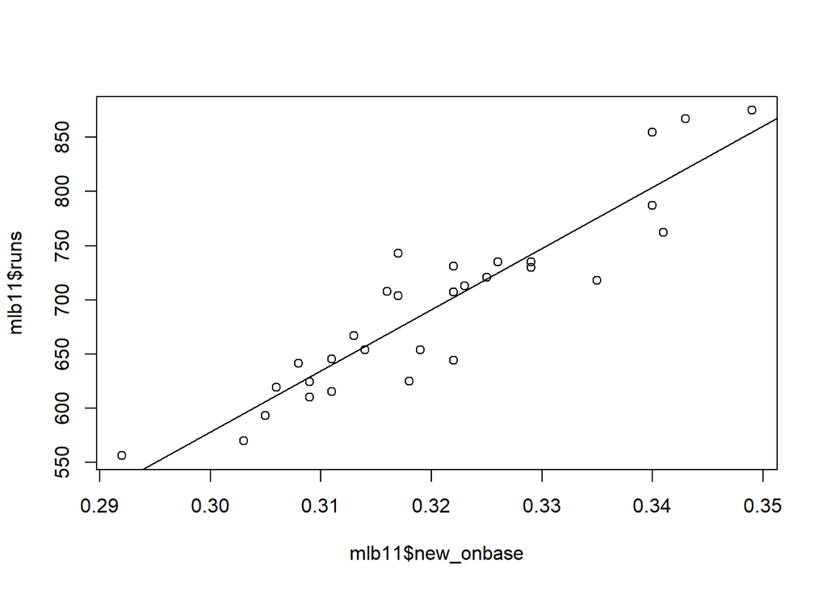

```r
plot(mlb11$runs ~ mlb11$new_onbase)
abline(new_onbase)
```

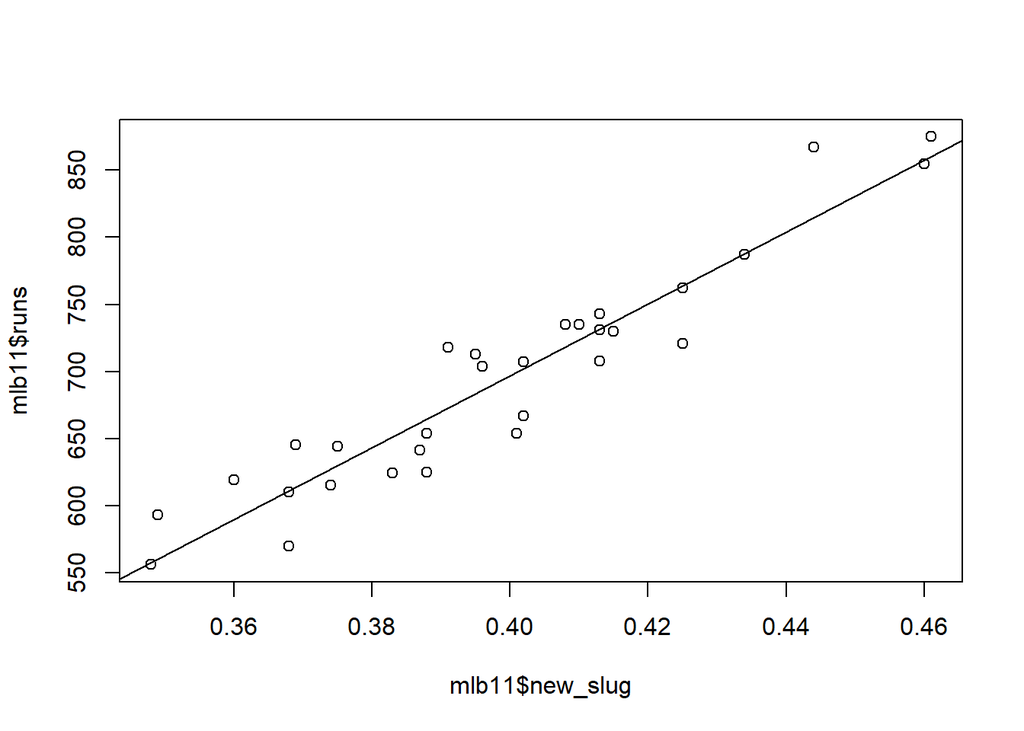

```r
plot(mlb11$runs ~ mlb11$new_slug)
abline(new_slug)
```

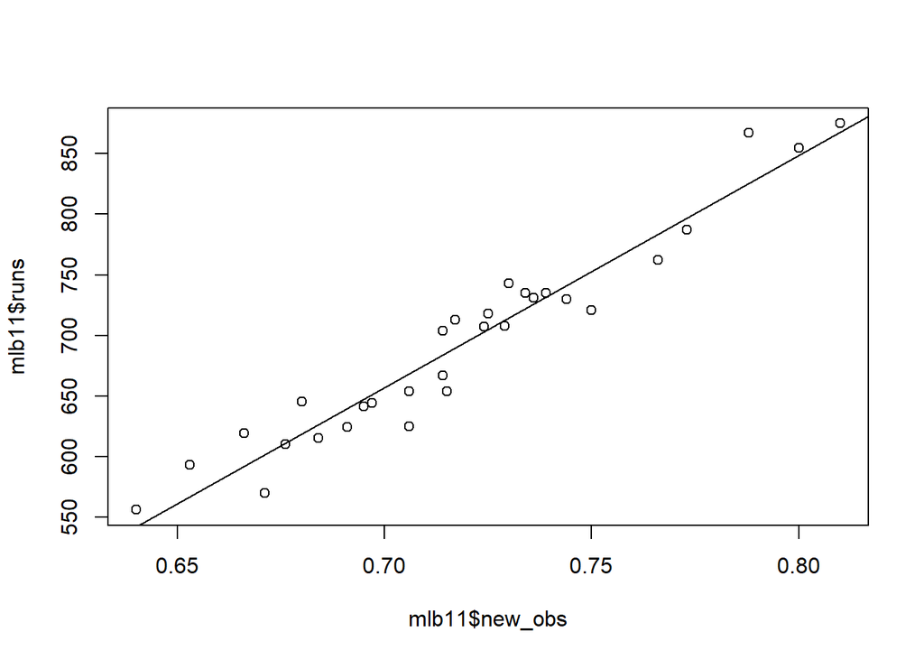

```r
plot(mlb11$runs ~ mlb11$new_obs)
abline(new_obs)
```

5. Check the model diagnostics for the regression model with the variable you decided was the best predictor for runs.

new_obs is the best predictor.

Linearity

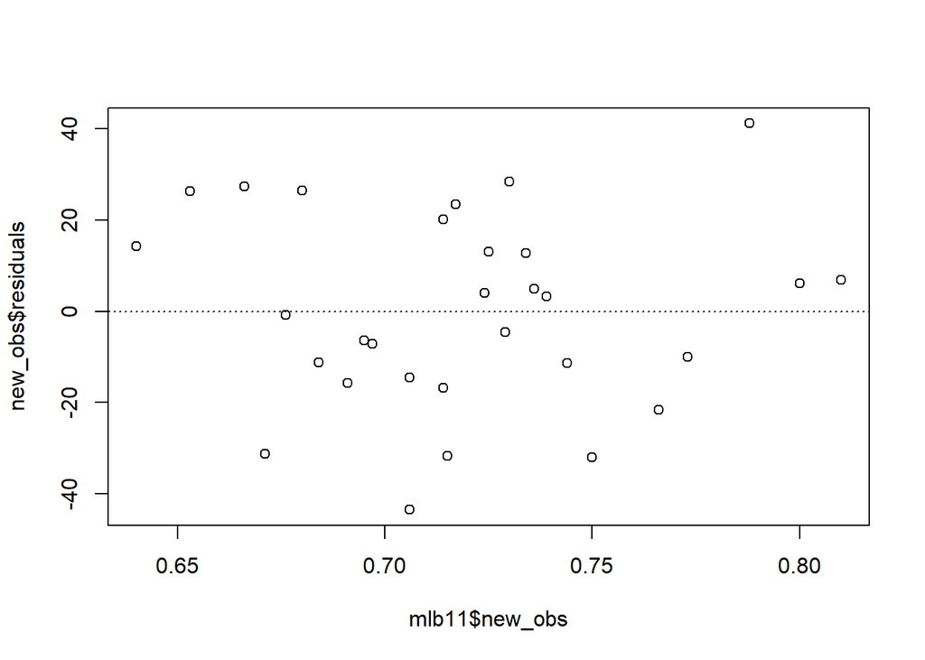

```r
plot(new_obs$residuals ~ mlb11$new_obs)
abline(h = 0, lty = 3)  # adds a horizontal dashed line at y = 0
```

The relationship looks linear based on a residual plot as the variability of residuals is approximately constant across the distribution but does not indicate any curvatures or any indication of non-normality.

Normal residuals:

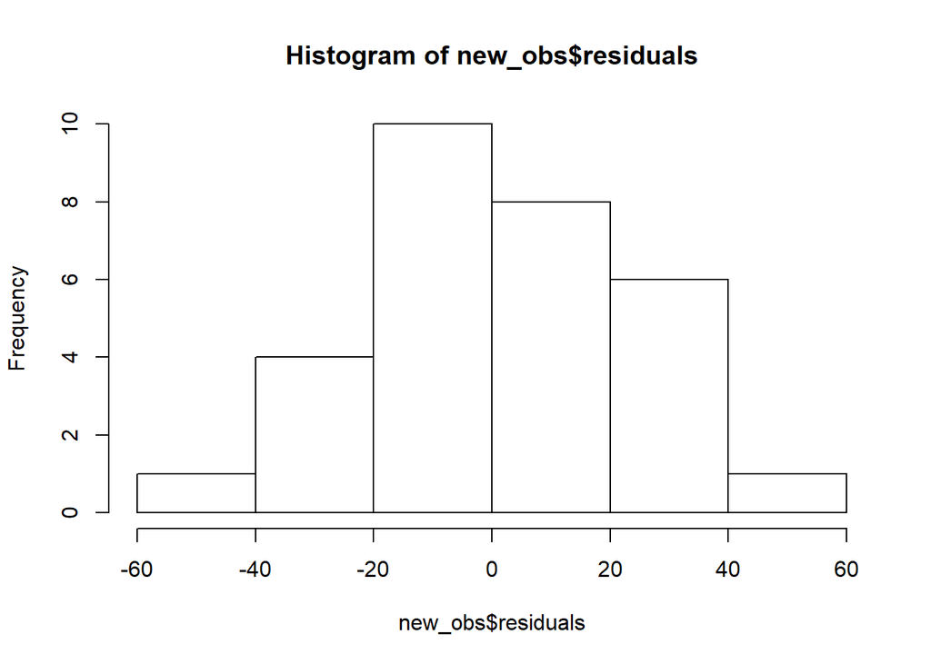

```r
hist(new_obs$residuals)
```

The residuals are approximately normaly distributed.

Constant variability

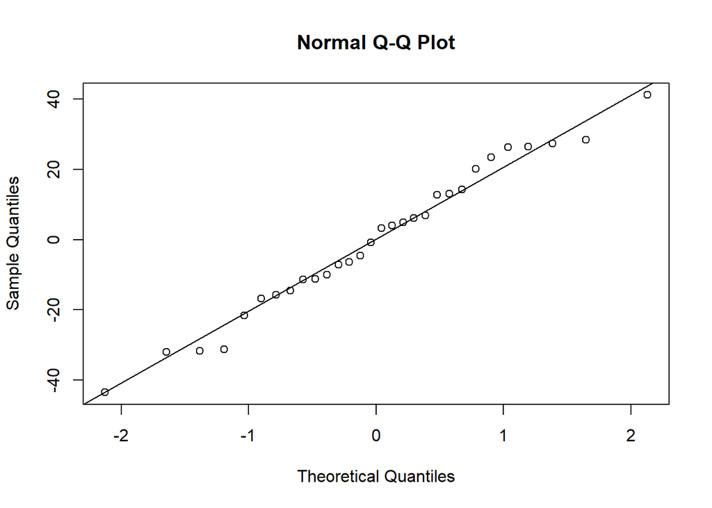

```r
qqnorm(new_obs$residuals)
qqline(new_obs$residuals)
```

The least squares line remains roughly constant so the condition constant variability has been met